# iCluster analysis of single cell multi-omics data

Qianxing Mo

Department of Biostatistics and Bioinformatics  
H. Lee Moffitt Cancer Center and Research Institute, Tampa, FL 33612

Compiled: March 20, 2026

We use the R scripts of the Seurat’s tutorial [Weighted Nearest Neighbor Analysis](https://satijalab.org/seurat/articles/weighted_nearest_neighbor_analysis) to process the scRNA-seq and ADT data. The iCluster analysis of single cell multi-omics data can be carried out in 4 steps as described in the following.

```r
library(iClusterPlus)
library(lattice)
library(gplots)
library(Seurat)
library(SeuratData)
library(cowplot)
library(dplyr)
library(Rphenograph)
library(umap)
library(mclust)
library(knitr)
```

# Step 1: Processing data using the Seurat package

The scRNA-seq and ADT data are processed separately, which includes normalization, feature selection, scaling and dimension reduction.

```r
InstallData("bmcite")
bm <- LoadData(ds = "bmcite")
DefaultAssay(bm) <- 'RNA'
bm <- NormalizeData(bm) %>% FindVariableFeatures() %>% ScaleData() %>% RunPCA()

# process ADT data; all the 25 features are used for dimensional reduction
DefaultAssay(bm) <- 'ADT'
VariableFeatures(bm) <- rownames(bm[["ADT"]])
bm <- NormalizeData(bm, normalization.method = 'CLR', margin = 2) %>% ScaleData() %>% RunPCA(reduction.name = 'apca')
```

# Step 2: Perform iCluster modeling

The iCluster modeling generates a latent factor matrix (meanZ), which capture the major sources of variation of the multi-omics data (scRNA-seq and ADT). As a result, the latent factor matrix can be used for sample clustering and visualization.

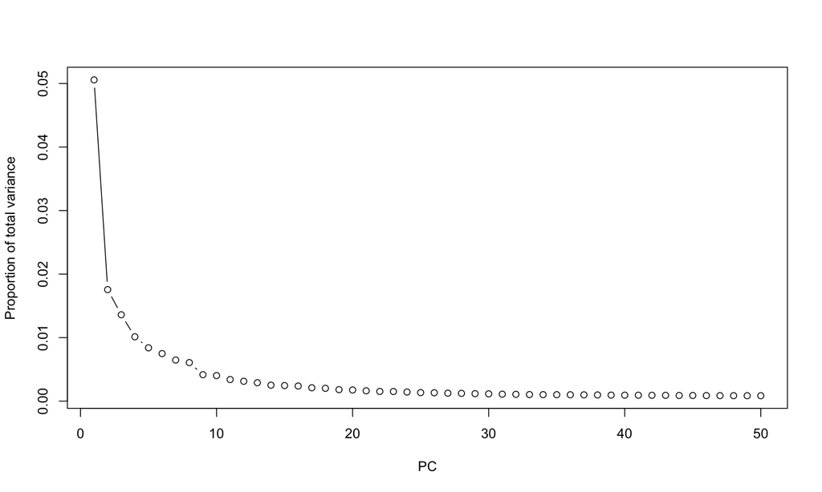

```r
# input data for iCluster2b
BMlist <- list(ADT=t(bm[['ADT']]$scale.data),RNA=t(bm[['RNA']]$scale.data))

# PCA variance plot
pcaVarPlot(BMlist,K=50)
```

From the variance plot, we can see that the explained variance starts to level off around the 10th PC. For iCluster modeling of single cell multi-omics data, we suggest selecting the PC at which the explained variance levels off. As an example, we select K=20 as the number of latent factors for iCluster modeling. It can be seen that the clustering results are quite consistent for a range of numbers (e.g., K = 20 - 30).

```r
# since features have been selected, we set lambda to a small value to minimize feature selection
date()
```

```
## [1] "Fri Mar 20 15:17:15 2026"
```

```r
bm.ic = iCluster2b(xList=BMlist,K=20,lambda=list(0.1,0.1),method=c("lasso","lasso"))
date()
```

```
## [1] "Fri Mar 20 15:17:32 2026"
```

# Step 3: Clustering of cells using the latent factor matrix

We use the Louvain method implemented in the Rphenograph package to perform cell clustering analysis. Then, we project the cells to a 2-dimensional space using UMAP for visualization.

```r
## clustering of cells using Louvain method and the latent factor matrix generated by iCluster
ic.graph <- Rphenograph(bm.ic$meanZ, k=30)
```

```
##   Finding nearest neighbors...DONE ~ 4.307 s
##   Compute jaccard coefficient between nearest-neighbor sets...DONE ~ 5.078 s
##   Build undirected graph from the weighted links...DONE ~ 0.906 s
##   Run louvain clustering on the graph ...DONE ~ 1.35 s
```

```
##   Return a community class
##   -Modularity value: 0.9018461
##   -Number of clusters: 25
```

```r
tabclst <- table(membership(ic.graph[[2]]))

## order the clusters based on cluster size
clstlevels <- as.numeric(names(tabclst)[order(tabclst,decreasing = TRUE)])
bm.iClusters <- factor(membership(ic.graph[[2]]),levels=clstlevels)
names(bm.iClusters) <- rownames(BMlist$ADT)

# Projecting cells to 2-dimensional space using UMAP
ic.umap <- umap(bm.ic$meanZ)
rownames(ic.umap$layout) <- rownames(BMlist$ADT)
colnames(ic.umap$layout) <- c("umap1","umap2")

## put umap layout and cluster IDs into the Seurat object bm
bm[["ic.umap"]] <- CreateDimReducObject(embeddings = ic.umap$layout, key = "ic_umap")
bm$iCluster <- bm.iClusters
```

For comparison, we perform unsupervised clustering analysis using Seurat’s WNN method. For more details of WNN analysis, we refer users to the Seurat’s tutorial ([Weighted Nearest Neighbor Analysis](https://satijalab.org/seurat/articles/weighted_nearest_neighbor_analysis)).

```r
# Generate WNN graph
bm <- FindMultiModalNeighbors(bm, reduction.list = list("pca", "apca"),dims.list <- list(1:30, 1:18), k.nn = 20,
   knn.graph.name = "wknn",snn.graph.name = "wsnn",modality.weight.name = "RNA.weight")
# multimodal neighbor matrix used for UMAP can be accessed using bm[['weighted.nn']]
# WNN graph can be accessed using bm[["wknn"]]
# SNN graph used for clustering can be accessed at bm[["wsnn"]]

bm <- RunUMAP(bm, nn.name = "weighted.nn", reduction.name = "wnn.umap", reduction.key = "wnnUMAP_")
bm <- FindClusters(bm, graph.name = "wsnn", algorithm = 3, resolution = 2, verbose = FALSE)
```

# Step 4: Visualization of cell clusters

We use Seurat’s function DimPlot to visualize the cells on a 2-dimensional UMAP space.

1. Visualization of cell clusters generated by iCluster analysis, alongside cell annotations

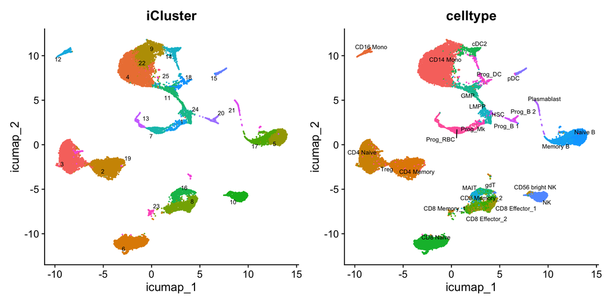

```r
p1 <- DimPlot(bm, reduction = "ic.umap", group.by = "iCluster", label = TRUE, label.size = 2.5, repel = TRUE) + NoLegend() + ggtitle("iCluster")
p2 <- DimPlot(bm, reduction = "ic.umap", group.by = "celltype.l2", label = TRUE, label.size = 2.5, repel = TRUE) + NoLegend() + ggtitle("celltype")
p1 + p2
```

2. Heatmap of cell clusters generated by iCluster analysis

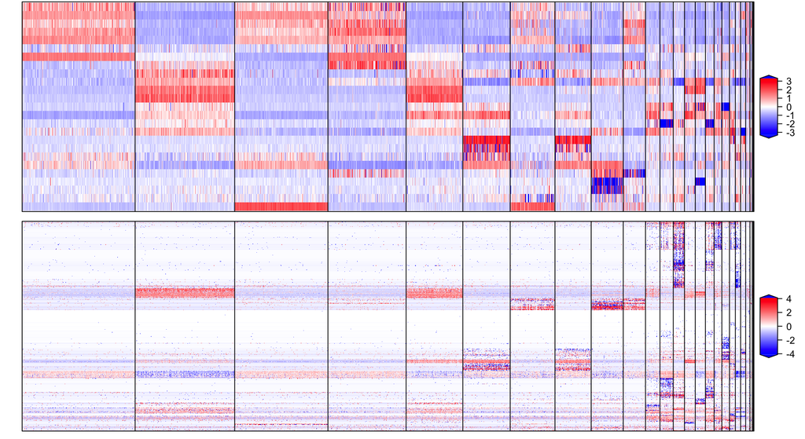

```r
col.scheme <- alist()
col.scheme[[1]] <- bluered(256)
col.scheme[[2]] <- bluered(256)

bm.ic$clusters <- bm.iClusters
ic.hm <- plotHeatmap(fit=bm.ic,xList=BMlist,type=c("gaussian","gaussian"),
            threshold=rep(0.25, 2),feature.order=c(T,T),feature.scale=c(F,F),
            dist.method = "euclidean", hclust.method="ward.D",col.scheme = col.scheme,width=10,
            sparse=c(F,T),cap=c(0.99,0.99))
```

3. Visualization of cell clusters generated by Seurat WNN analysis, alongside cell annotations

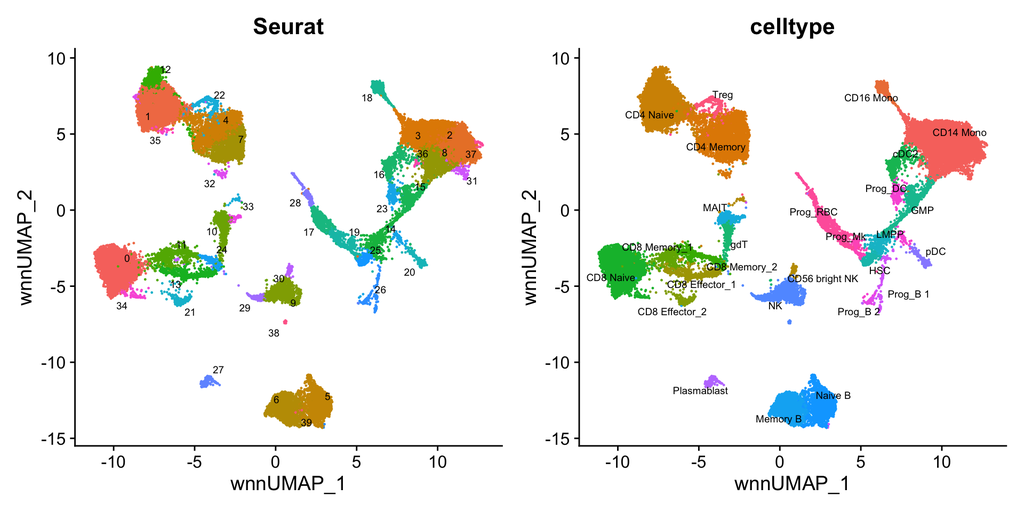

```r
p3 <- DimPlot(bm, reduction = "wnn.umap", group.by = "seurat_clusters", label = TRUE, label.size = 2.5, repel = TRUE) + NoLegend() + ggtitle("Seurat")
p4 <- DimPlot(bm, reduction = "wnn.umap", group.by = "celltype.l2", label = TRUE, label.size = 2.5, repel = TRUE) + NoLegend() + ggtitle("celltype")
p3 + p4
```

4. Heatmap of cell clusters generated by Seurat WNN analysis

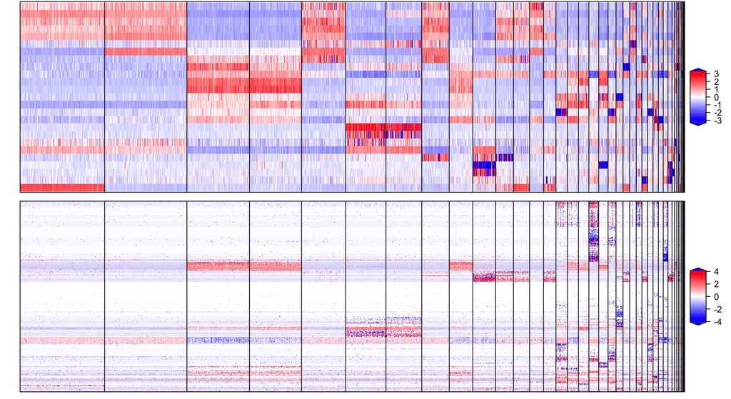

```r
bm.ic$clusters <- bm$seurat_clusters
wnn.hm <- plotHeatmap(fit=bm.ic,xList=BMlist,type=c("gaussian","gaussian"),
            threshold=rep(0.25, 2),feature.order=c(T,T),feature.scale=c(F,F),
            dist.method = "euclidean", hclust.method="ward.D",col.scheme = col.scheme,width=10,
            sparse=c(F,T),cap=c(0.99,0.99))
```

Finally, we compare the integrative clustering results of the iCluster and Seurat WNN using adjusted rand index. In general, the higher of the index, the better the results.

```r
# iCluster vs. cell type annotation
adjustedRandIndex(bm$iCluster, bm$celltype.l2)
```

```
## [1] 0.7788463
```

```r
# seurat WNN clusters vs. cell type annotation
adjustedRandIndex(bm$seurat_clusters, bm$celltype.l2)
```

```
## [1] 0.7188821
```

```r
# iClusters vs. seurat WNN clusters
adjustedRandIndex(bm$iCluster, bm$seurat_clusters)
```

```
## [1] 0.6997139
```

```r
# table of annotated cell types and iClusters
icTable <- table(bm$celltype.l2,bm.iClusters)
knitr::kable(icTable)
```

|  | 3 | 4 | 6 | 2 | 9 | 5 | 8 | 17 | 10 | 16 | 11 | 24 | 7 | 14 | 12 | 1 | 18 | 15 | 20 | 13 | 21 | 19 | 23 | 22 | 25 |
| --- | --- | --- | --- | --- | --- | --- | --- | --- | --- | --- | --- | --- | --- | --- | --- | --- | --- | --- | --- | --- | --- | --- | --- | --- | --- |
| CD14 Mono | 0 | 4127 | 0 | 0 | 2232 | 0 | 1 | 0 | 0 | 1 | 12 | 0 | 0 | 4 | 6 | 2 | 5 | 0 | 0 | 3 | 0 | 28 | 0 | 40 | 25 |
| CD16 Mono | 0 | 0 | 0 | 0 | 12 | 0 | 0 | 0 | 0 | 0 | 0 | 0 | 0 | 0 | 420 | 0 | 0 | 0 | 0 | 0 | 0 | 1 | 0 | 0 | 0 |
| CD4 Memory | 221 | 0 | 0 | 3085 | 0 | 0 | 2 | 1 | 0 | 5 | 0 | 0 | 0 | 0 | 0 | 0 | 5 | 0 | 0 | 0 | 0 | 22 | 19 | 0 | 0 |
| CD4 Naive | 4345 | 1 | 1 | 56 | 0 | 0 | 0 | 1 | 0 | 1 | 0 | 0 | 0 | 0 | 0 | 0 | 1 | 0 | 1 | 0 | 0 | 73 | 20 | 0 | 0 |
| CD56 bright NK | 3 | 1 | 0 | 3 | 0 | 0 | 9 | 0 | 103 | 1 | 0 | 0 | 0 | 0 | 0 | 0 | 1 | 0 | 0 | 0 | 0 | 2 | 20 | 0 | 0 |
| CD8 Effector_1 | 0 | 0 | 2 | 0 | 0 | 0 | 552 | 0 | 2 | 14 | 0 | 0 | 0 | 0 | 0 | 0 | 0 | 0 | 0 | 0 | 0 | 3 | 4 | 0 | 0 |
| CD8 Effector_2 | 0 | 1 | 3 | 1 | 1 | 0 | 294 | 0 | 0 | 5 | 0 | 0 | 0 | 0 | 0 | 0 | 0 | 0 | 0 | 0 | 0 | 2 | 0 | 0 | 0 |
| CD8 Memory_1 | 0 | 0 | 10 | 0 | 0 | 0 | 406 | 0 | 0 | 21 | 0 | 0 | 0 | 0 | 0 | 0 | 0 | 0 | 0 | 0 | 0 | 0 | 7 | 0 | 0 |
| CD8 Memory_2 | 0 | 1 | 1 | 1 | 0 | 0 | 503 | 0 | 1 | 37 | 1 | 0 | 0 | 1 | 0 | 0 | 3 | 0 | 0 | 0 | 0 | 6 | 0 | 0 | 0 |
| CD8 Naive | 1 | 1 | 3889 | 0 | 1 | 0 | 62 | 0 | 0 | 0 | 0 | 0 | 0 | 0 | 0 | 0 | 0 | 0 | 0 | 0 | 0 | 0 | 20 | 0 | 0 |
| cDC2 | 0 | 13 | 0 | 0 | 120 | 0 | 0 | 0 | 0 | 0 | 0 | 0 | 1 | 347 | 0 | 0 | 0 | 0 | 0 | 0 | 0 | 1 | 0 | 0 | 0 |
| gdT | 0 | 0 | 0 | 2 | 0 | 0 | 13 | 0 | 0 | 349 | 0 | 0 | 0 | 0 | 0 | 0 | 0 | 0 | 0 | 0 | 0 | 3 | 0 | 0 | 0 |
| GMP | 0 | 23 | 0 | 0 | 4 | 0 | 0 | 0 | 0 | 0 | 573 | 8 | 0 | 2 | 0 | 0 | 136 | 0 | 0 | 2 | 0 | 0 | 0 | 0 | 0 |
| HSC | 1 | 0 | 0 | 0 | 0 | 0 | 0 | 0 | 0 | 1 | 0 | 247 | 0 | 0 | 0 | 12 | 0 | 0 | 0 | 0 | 0 | 2 | 0 | 0 | 0 |
| LMPP | 1 | 0 | 0 | 0 | 0 | 0 | 0 | 0 | 0 | 0 | 15 | 264 | 0 | 1 | 0 | 8 | 2 | 0 | 1 | 0 | 0 | 0 | 0 | 0 | 0 |
| MAIT | 0 | 1 | 0 | 1 | 0 | 0 | 26 | 0 | 0 | 488 | 0 | 0 | 0 | 0 | 0 | 0 | 0 | 0 | 0 | 0 | 0 | 1 | 3 | 0 | 0 |
| Memory B | 0 | 0 | 1 | 0 | 0 | 229 | 0 | 1389 | 1 | 1 | 0 | 0 | 0 | 0 | 0 | 0 | 0 | 0 | 0 | 0 | 0 | 8 | 1 | 0 | 0 |
| Naive B | 0 | 0 | 0 | 0 | 0 | 1756 | 0 | 117 | 0 | 0 | 0 | 0 | 0 | 0 | 0 | 0 | 0 | 0 | 8 | 0 | 0 | 15 | 0 | 0 | 4 |
| NK | 0 | 1 | 1 | 0 | 0 | 0 | 6 | 0 | 1237 | 8 | 1 | 0 | 0 | 0 | 0 | 0 | 8 | 0 | 0 | 0 | 0 | 4 | 1 | 0 | 0 |
| pDC | 0 | 0 | 0 | 0 | 0 | 0 | 0 | 0 | 0 | 0 | 0 | 3 | 0 | 6 | 0 | 1 | 0 | 318 | 0 | 0 | 0 | 0 | 0 | 0 | 0 |
| Plasmablast | 0 | 1 | 0 | 0 | 0 | 0 | 0 | 7 | 0 | 0 | 0 | 0 | 0 | 0 | 0 | 0 | 1 | 0 | 0 | 1 | 211 | 1 | 1 | 0 | 0 |
| Prog_B 1 | 0 | 0 | 0 | 0 | 0 | 0 | 0 | 1 | 0 | 0 | 0 | 31 | 0 | 0 | 0 | 0 | 0 | 0 | 111 | 1 | 0 | 0 | 1 | 0 | 0 |
| Prog_B 2 | 0 | 0 | 0 | 0 | 0 | 0 | 0 | 0 | 0 | 0 | 0 | 0 | 0 | 0 | 0 | 0 | 4 | 0 | 125 | 0 | 0 | 0 | 0 | 0 | 0 |
| Prog_DC | 0 | 2 | 0 | 0 | 6 | 0 | 0 | 0 | 0 | 0 | 4 | 2 | 0 | 91 | 0 | 0 | 155 | 2 | 0 | 1 | 0 | 0 | 0 | 0 | 0 |
| Prog_Mk | 0 | 0 | 0 | 0 | 0 | 0 | 0 | 0 | 0 | 0 | 0 | 2 | 0 | 0 | 0 | 119 | 0 | 0 | 0 | 0 | 0 | 3 | 0 | 0 | 0 |
| Prog_RBC | 1 | 0 | 0 | 0 | 2 | 0 | 2 | 1 | 0 | 0 | 0 | 1 | 468 | 0 | 0 | 223 | 1 | 0 | 0 | 213 | 0 | 1 | 2 | 0 | 0 |
| Treg | 163 | 0 | 1 | 126 | 0 | 0 | 1 | 0 | 0 | 1 | 0 | 0 | 0 | 0 | 0 | 0 | 2 | 0 | 0 | 0 | 0 | 3 | 0 | 0 | 0 |